# Regression Model for Wine Quality Using R

David Lowe

July 23, 2018

Template Credit: Adapted from a template made available by Dr. Jason Brownlee of Machine Learning Mastery. [http://machinelearningmastery.com/]

SUMMARY: The purpose of this project is to construct a prediction model using various machine learning algorithms and to document the end-to-end steps using a template. The Wine Quality dataset can be approached as a regression situation where we are trying to predict the rating of the wine.

INTRODUCTION: The two datasets are related to red and white variants of the Portuguese “Vinho Verde” wine. Due to privacy and logistic issues, only physicochemical (inputs) and sensory (the output) variables are available (e.g. there is no data about grape types, wine brand, wine selling price, etc.). The goal is to model wine quality based on physicochemical tests.

CONCLUSION: The baseline performance of the seven algorithms achieved an average RMSE of 0.7119. Three algorithms (Support Vector Machine, Random Forest, and Stochastic Gradient Boosting) achieved the top RMSE scores after the first round of modeling. After a series of tuning trials, Random Forest turned in the top result using the training data. It achieved an average RMSE of 0.6088. Using the optimized tuning parameter available, the Random Forest algorithm processed the validation dataset with an RMSE of 0.6416, which was slight worse than the RMSE of the training data. For this project, the Random Forest ensemble algorithm yielded consistently top-notch training and validation results, which warrant the additional processing required by the algorithm.

Dataset Used: Wine Quality Data Set

Dataset ML Model: Regression with numerical attributes

Dataset Reference: https://archive.ics.uci.edu/ml/datasets/wine+quality

One potential source of performance benchmarks: https://www.kaggle.com/uciml/red-wine-quality-cortez-et-al-2009

The project aims to touch on the following areas:

1. Document a predictive modeling problem end-to-end.
2. Explore data cleaning and transformation options
3. Explore non-ensemble and ensemble algorithms for baseline model performance
4. Explore algorithm tuning techniques for improving model performance

Any predictive modeling machine learning project genrally can be broken down into about six major tasks:

1. Prepare Problem
2. Summarize Data
3. Prepare Data
4. Model and Evaluate Algorithms
5. Improve Accuracy or Results
6. Finalize Model and Present Results

## 1. Prepare Problem

### 1.a) Load libraries

```r
library(caret)
```

```r
library(corrplot)
```

### 1.b) Load dataset

```r
startTimeScript <- proc.time()
entireDataset <- read.csv("winequality-all.csv", header= TRUE)

# Rename the class/target column to a standard label
colnames(entireDataset)[ncol(entireDataset)] <- "targetVar"

# Use variable totCol to hold the number of columns in the dataframe
totCol <- ncol(entireDataset)
```

## 2. Summarize Data

To gain a better understanding of the data that we have on-hand, we will leverage a number of descriptive statistics and data visualization techniques. The plan is to use the results to consider new questions, review assumptions, and validate hypotheses that we can investigate later with specialized models.

### 2.a) Descriptive statistics

#### 2.a.i) Peek at the data itself.

```r
head(entireDataset)
```

```
##   fixed.acidity volatile.acidity citric.acid residual.sugar chlorides
## 1           7.0             0.27        0.36           20.7     0.045
## 2           6.3             0.30        0.34            1.6     0.049
## 3           8.1             0.28        0.40            6.9     0.050
## 4           7.2             0.23        0.32            8.5     0.058
## 5           7.2             0.23        0.32            8.5     0.058
## 6           8.1             0.28        0.40            6.9     0.050
##   free.sulfur.dioxide total.sulfur.dioxide density   pH sulphates alcohol
## 1                  45                  170  1.0010 3.00      0.45     8.8
## 2                  14                  132  0.9940 3.30      0.49     9.5
## 3                  30                   97  0.9951 3.26      0.44    10.1
## 4                  47                  186  0.9956 3.19      0.40     9.9
## 5                  47                  186  0.9956 3.19      0.40     9.9
## 6                  30                   97  0.9951 3.26      0.44    10.1
##   color_white targetVar
## 1           1         6
## 2           1         6
## 3           1         6
## 4           1         6
## 5           1         6
## 6           1         6
```

#### 2.a.ii) Dimensions of the dataset.

```r
dim(entireDataset)
```

```
## [1] 6497   13
```

#### 2.a.iii) Types of the attributes.

```r
sapply(entireDataset, class)
```

```
##        fixed.acidity     volatile.acidity          citric.acid
##            "numeric"            "numeric"            "numeric"
##       residual.sugar            chlorides  free.sulfur.dioxide
##            "numeric"            "numeric"            "numeric"
## total.sulfur.dioxide              density                   pH
##            "numeric"            "numeric"            "numeric"
##            sulphates              alcohol          color_white
##            "numeric"            "numeric"            "integer"
##            targetVar
##            "integer"
```

#### 2.a.iv) Statistical summary of all attributes.

```r
summary(entireDataset)
```

```
##  fixed.acidity    volatile.acidity  citric.acid     residual.sugar
##  Min.   : 3.800   Min.   :0.0800   Min.   :0.0000   Min.   : 0.600
##  1st Qu.: 6.400   1st Qu.:0.2300   1st Qu.:0.2500   1st Qu.: 1.800
##  Median : 7.000   Median :0.2900   Median :0.3100   Median : 3.000
##  Mean   : 7.215   Mean   :0.3397   Mean   :0.3186   Mean   : 5.443
##  3rd Qu.: 7.700   3rd Qu.:0.4000   3rd Qu.:0.3900   3rd Qu.: 8.100
##  Max.   :15.900   Max.   :1.5800   Max.   :1.6600   Max.   :65.800
##    chlorides       free.sulfur.dioxide total.sulfur.dioxide
##  Min.   :0.00900   Min.   :  1.00      Min.   :  6.0
##  1st Qu.:0.03800   1st Qu.: 17.00      1st Qu.: 77.0
##  Median :0.04700   Median : 29.00      Median :118.0
##  Mean   :0.05603   Mean   : 30.53      Mean   :115.7
##  3rd Qu.:0.06500   3rd Qu.: 41.00      3rd Qu.:156.0
##  Max.   :0.61100   Max.   :289.00      Max.   :440.0
##     density             pH          sulphates         alcohol
##  Min.   :0.9871   Min.   :2.720   Min.   :0.2200   Min.   : 8.00
##  1st Qu.:0.9923   1st Qu.:3.110   1st Qu.:0.4300   1st Qu.: 9.50
##  Median :0.9949   Median :3.210   Median :0.5100   Median :10.30
##  Mean   :0.9947   Mean   :3.219   Mean   :0.5313   Mean   :10.49
##  3rd Qu.:0.9970   3rd Qu.:3.320   3rd Qu.:0.6000   3rd Qu.:11.30
##  Max.   :1.0390   Max.   :4.010   Max.   :2.0000   Max.   :14.90
##   color_white       targetVar
##  Min.   :0.0000   Min.   :3.000
##  1st Qu.:1.0000   1st Qu.:5.000
##  Median :1.0000   Median :6.000
##  Mean   :0.7539   Mean   :5.818
##  3rd Qu.:1.0000   3rd Qu.:6.000
##  Max.   :1.0000   Max.   :9.000
```

#### 2.a.v) Count missing values.

```r
sapply(entireDataset, function(x) sum(is.na(x)))
```

```
##        fixed.acidity     volatile.acidity          citric.acid
##                    0                    0                    0
##       residual.sugar            chlorides  free.sulfur.dioxide
##                    0                    0                    0
## total.sulfur.dioxide              density                   pH
##                    0                    0                    0
##            sulphates              alcohol          color_white
##                    0                    0                    0
##            targetVar
##                    0
```

### 2.b) Data visualizations

```r
# Set up a variable for the total number of attribute columns (totAttr)
totAttr <- totCol-1
# Set up the number of row and columns for visualization display. dispRow * dispCol should be >= totAttr
dispCol <- 4
if (totAttr%%dispCol == 0) {
dispRow <- totAttr%/%dispCol
} else {
dispRow <- (totAttr%/%dispCol) + 1
}
cat("Will attempt to create graphics grid (col x row): ", dispCol, ' by ', dispRow)
```

```
## Will attempt to create graphics grid (col x row):  4  by  3
```

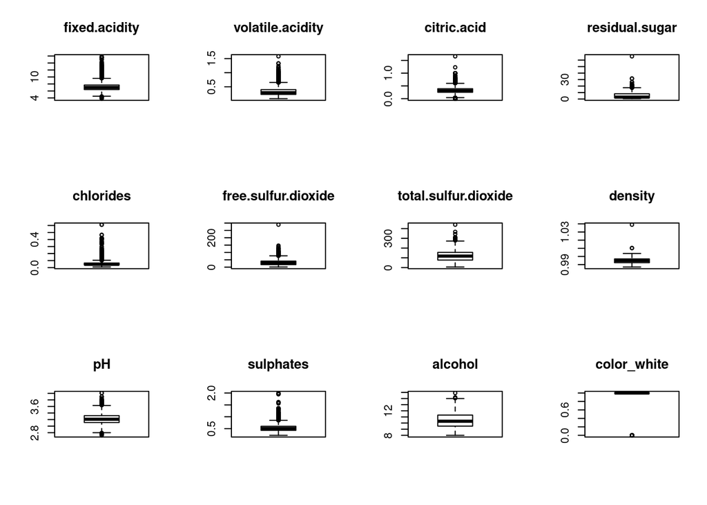

```r
# Boxplots for each attribute
par(mfrow=c(dispRow,dispCol))
for(i in 1:totAttr) {
    boxplot(entireDataset[,i], main=names(entireDataset)[i])
}
```

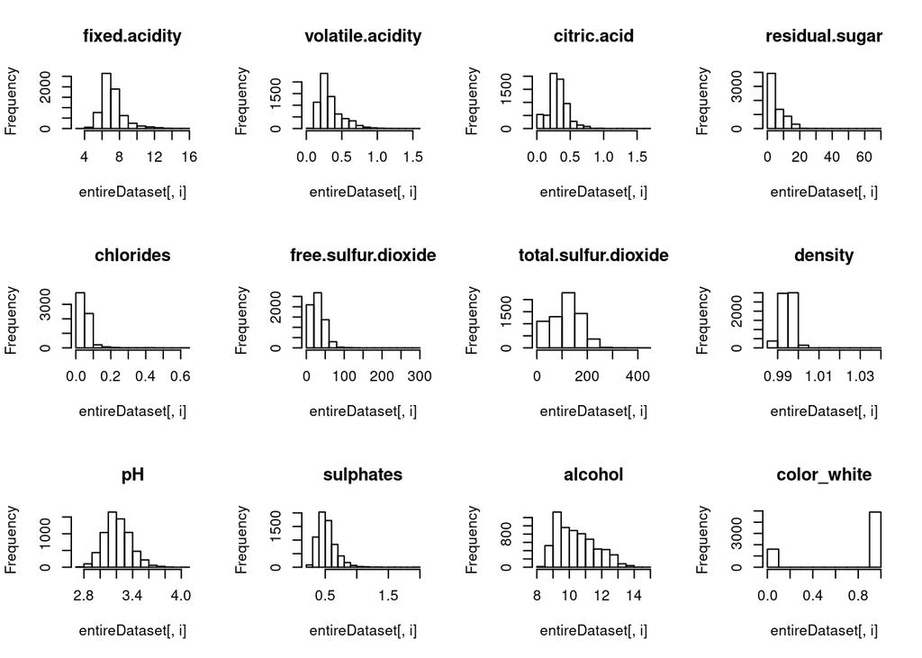

```r
# Histograms each attribute
par(mfrow=c(dispRow,dispCol))
for(i in 1:totAttr) {
    hist(entireDataset[,i], main=names(entireDataset)[i])
}
```

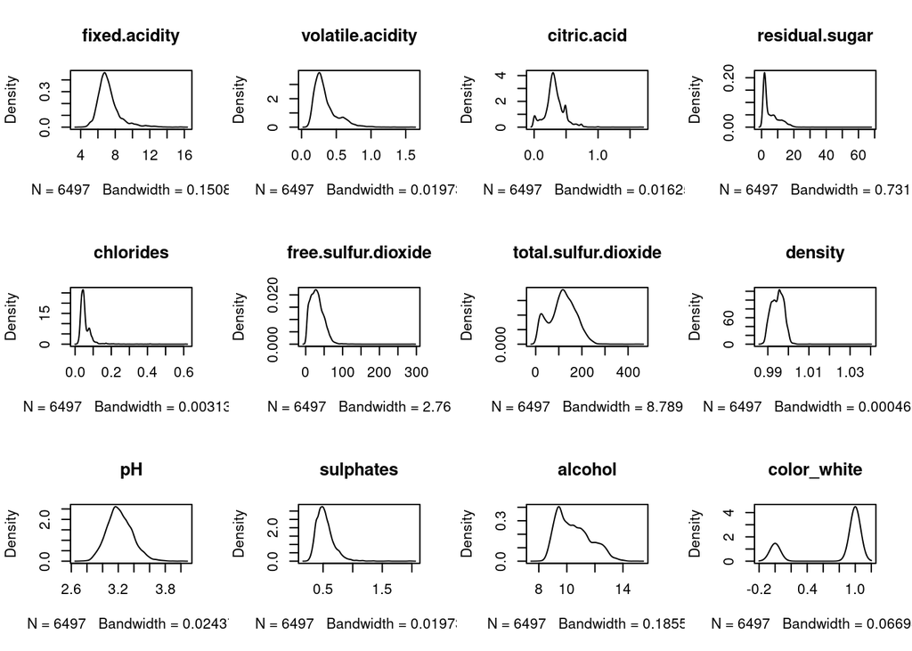

```r
# Density plot for each attribute
par(mfrow=c(dispRow,dispCol))
for(i in 1:totAttr) {
    plot(density(entireDataset[,i]), main=names(entireDataset)[i])
}
```

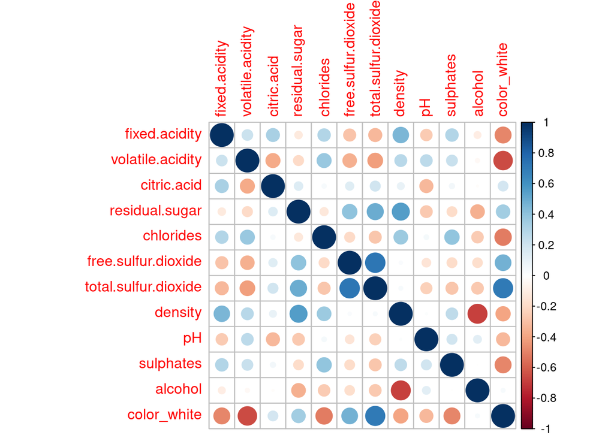

```r
# Correlation plot
correlations <- cor(entireDataset[,1:totAttr])
corrplot(correlations, method="circle")
```

## 3. Prepare Data

Some dataset may require additional preparation activities that will best exposes the structure of the problem and the relationships between the input attributes and the output variable. Some data-prep tasks might include:

- Cleaning data by removing duplicates, marking missing values and even imputing missing values.
- Feature selection where redundant features may be removed.
- Data transforms where attributes are scaled or redistributed in order to best expose the structure of the problem later to learning algorithms.

### 3.a) Data Cleaning

```r
# Not applicable for this iteration of the project.

# Mark missing values
#invalid <- 0
#entireDataset$some_col[entireDataset$some_col==invalid] <- NA

# Impute missing values
#entireDataset$some_col <- with(entireDataset, impute(some_col, mean))
```

### 3.b) Feature Selection

```r
# Not applicable for this iteration of the project.
```

### 3.c) Data Transforms

```r
# Not applicable for this iteration of the project.
```

### 3.d) Split-out training and validation datasets

We create a training dataset (variable name “training”) and a validation dataset (variable name “validation”).

```r
seedNum <- 888
set.seed(seedNum)

# Create a list of 70% of the rows in the original dataset we can use for training
training_index <- createDataPartition(entireDataset$targetVar, p=0.70, list=FALSE)

# Use 70% of data to training and testing the models
training <- entireDataset[training_index,]

# Select the remaining 30% of the data for validation
validation <- entireDataset[-training_index,]
```

```r
proc.time()-startTimeScript
```

```
##    user  system elapsed
##   1.177   0.261   1.495
```

## 4. Model and Evaluate Algorithms

After the data-prep, we next work on finding a workable model by evaluating a subset of machine learning algorithms that are good at exploiting the structure of the dataset. The typical evaluation tasks include:

- Defining test options such as cross validation and the evaluation metric to use.
- Spot checking a suite of linear and nonlinear machine learning algorithms.
- Comparing the estimated accuracy of algorithms.

For this project, we will evaluate one linear, three non-linear, and three ensemble algorithms:

Linear Algorithm: Linear Regression

Non-Linear Algorithms: Decision Trees (CART), k-Nearest Neighbors, and Support Vector Machine

Ensemble Algorithms: Bagged CART, Random Forest, and Stochastic Gradient Boosting

The random number seed is reset before each run to ensure that the evaluation of each algorithm is performed using the same data splits. It ensures the results are directly comparable.

### 4.a) Set test options and evaluation metric

```r
# Run algorithms using 10-fold cross validation
control <- trainControl(method="repeatedcv", number=10, repeats=3)
metricTarget <- "RMSE"
```

### 4.b) Generate models using linear algorithms

```r
# Linear Regression (Regression)
startTimeModule <- proc.time()
set.seed(seedNum)
fit.lm <- train(targetVar~., data=training, method="lm", metric=metricTarget, trControl=control)
proc.time()-startTimeModule
```

```
##    user  system elapsed
##    1.44    0.00    1.46
```

### 4.c) Generate models using nonlinear algorithms

```r
# Decision Tree - CART (Regression/Classification)
startTimeModule <- proc.time()
set.seed(seedNum)
fit.cart <- train(targetVar~., data=training, method="rpart", metric=metricTarget, trControl=control)
proc.time()-startTimeModule
```

```
##    user  system elapsed
##   2.335   0.000   2.384
```

```r
# k-Nearest Neighbors (Regression/Classification)
startTimeModule <- proc.time()
set.seed(seedNum)
fit.knn <- train(targetVar~., data=training, method="knn", metric=metricTarget, trControl=control)
proc.time()-startTimeModule
```

```
##    user  system elapsed
##   4.676   0.000   4.734
```

```r
# Support Vector Machine (Regression/Classification)
startTimeModule <- proc.time()
set.seed(seedNum)
fit.svm <- train(targetVar~., data=training, method="svmRadial", metric=metricTarget, trControl=control)
proc.time()-startTimeModule
```

```
##    user  system elapsed
## 169.762   2.508 174.266
```

### 4.d) Generate models using ensemble algorithms

In this section, we will explore the use and tuning of ensemble algorithms to see whether we can improve the results.

```r
# Bagged CART (Regression/Classification)
startTimeModule <- proc.time()
set.seed(seedNum)
fit.bagcart <- train(targetVar~., data=training, method="treebag", metric=metricTarget, trControl=control)
proc.time()-startTimeModule
```

```
##    user  system elapsed
##  16.709   0.012  16.951
```

```r
# Random Forest (Regression/Classification)
startTimeModule <- proc.time()
set.seed(seedNum)
fit.rf <- train(targetVar~., data=training, method="rf", metric=metricTarget, trControl=control)
proc.time()-startTimeModule
```

```
##     user   system  elapsed
## 1786.432    5.236 1813.572
```

```r
# Stochastic Gradient Boosting (Regression/Classification)
startTimeModule <- proc.time()
set.seed(seedNum)
fit.gbm <- train(targetVar~., data=training, method="gbm", metric=metricTarget, trControl=control, verbose=F)
proc.time()-startTimeModule
```

```
##    user  system elapsed
##  21.899   0.046  22.261
```

### 4.e) Compare baseline algorithms

```r
results <- resamples(list(LR=fit.lm, CART=fit.cart, kNN=fit.knn, SVM=fit.svm, BagCART=fit.bagcart, RF=fit.rf, GBM=fit.gbm))
summary(results)
```

```
##
## Call:
## summary.resamples(object = results)
##
## Models: LR, CART, kNN, SVM, BagCART, RF, GBM
## Number of resamples: 30
##
## MAE
##              Min.   1st Qu.    Median      Mean   3rd Qu.      Max. NA's
## LR      0.5322688 0.5489508 0.5661762 0.5631795 0.5751295 0.6000064    0
## CART    0.5677530 0.5923118 0.6099005 0.6052254 0.6209670 0.6341148    0
## kNN     0.6036651 0.6255211 0.6419382 0.6399745 0.6513863 0.7035198    0
## SVM     0.4826504 0.4940642 0.5104428 0.5090189 0.5226975 0.5429179    0
## BagCART 0.5483938 0.5585684 0.5796214 0.5770101 0.5898691 0.6038558    0
## RF      0.4232884 0.4432657 0.4550732 0.4548675 0.4659975 0.4799275    0
## GBM     0.5026621 0.5147392 0.5363206 0.5307414 0.5429520 0.5590828    0
##
## RMSE
##              Min.   1st Qu.    Median      Mean   3rd Qu.      Max. NA's
## LR      0.6825352 0.7065806 0.7232211 0.7222985 0.7351682 0.7601489    0
## CART    0.7105444 0.7504199 0.7704108 0.7657753 0.7835260 0.8136144    0
## kNN     0.7361075 0.7791609 0.8010863 0.8026680 0.8188271 0.8917502    0
## SVM     0.6388311 0.6511879 0.6722315 0.6723125 0.6916428 0.7049262    0
## BagCART 0.6847801 0.7111971 0.7360694 0.7310817 0.7490332 0.7700493    0
## RF      0.5757383 0.5951533 0.6105388 0.6102405 0.6267855 0.6489330    0
## GBM     0.6416953 0.6587434 0.6845687 0.6791576 0.6952934 0.7138399    0
##
## Rsquared
##               Min.   1st Qu.    Median      Mean   3rd Qu.      Max. NA's
## LR      0.24650996 0.2931832 0.3118687 0.3108490 0.3351859 0.3646573    0
## CART    0.18606493 0.2094351 0.2245306 0.2248340 0.2382624 0.2875267    0
## kNN     0.09169026 0.1469031 0.1706277 0.1626211 0.1826193 0.2149428    0
## SVM     0.35914589 0.3832423 0.4029477 0.4045443 0.4279085 0.4420696    0
## BagCART 0.25453617 0.2728286 0.2962289 0.2945385 0.3121957 0.3522406    0
## RF      0.48142861 0.5006780 0.5190096 0.5189160 0.5360548 0.5659621    0
## GBM     0.34621629 0.3677786 0.3927759 0.3906119 0.4072616 0.4439152    0
```

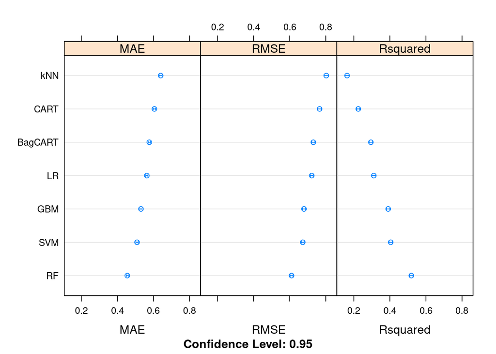

```r
dotplot(results)
```

## 5. Improve Accuracy or Results

After we achieve a short list of machine learning algorithms with good level of accuracy, we can leverage ways to improve the accuracy of the models.

Using the three best-perfoming algorithms from the previous section, we will Search for a combination of parameters for each algorithm that yields the best results.

### 5.a) Algorithm Tuning

Finally, we will tune the best-performing algorithms from each group further and see whether we can get more accuracy out of them.

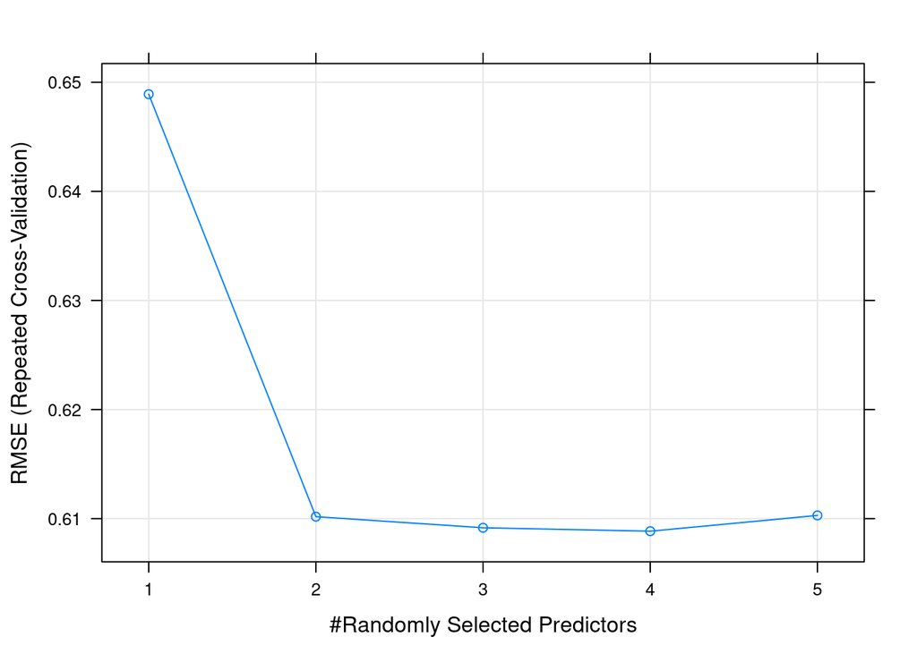

```r
# Tuning algorithm #1 - Random Forest
startTimeModule <- proc.time()
set.seed(seedNum)
grid <- expand.grid(mtry = c(1:5))
fit.final1 <- train(targetVar~., data=training, method="rf", metric=metricTarget, tuneGrid=grid, trControl=control)
plot(fit.final1)
```

```r
print(fit.final1)
```

```
## Random Forest
##
## 4549 samples
##   12 predictor
##
## No pre-processing
## Resampling: Cross-Validated (10 fold, repeated 3 times)
## Summary of sample sizes: 4095, 4095, 4094, 4096, 4093, 4093, ...
## Resampling results across tuning parameters:
##
##   mtry  RMSE       Rsquared   MAE
##   1     0.6489052  0.4871695  0.5076845
##   2     0.6101812  0.5188428  0.4550995
##   3     0.6091631  0.5170294  0.4514955
##   4     0.6088498  0.5159549  0.4498912
##   5     0.6102968  0.5124786  0.4500671
##
## RMSE was used to select the optimal model using the smallest value.
## The final value used for the model was mtry = 4.
```

```r
proc.time()-startTimeModule
```

```
##     user   system  elapsed
## 1617.071    3.845 1640.471
```

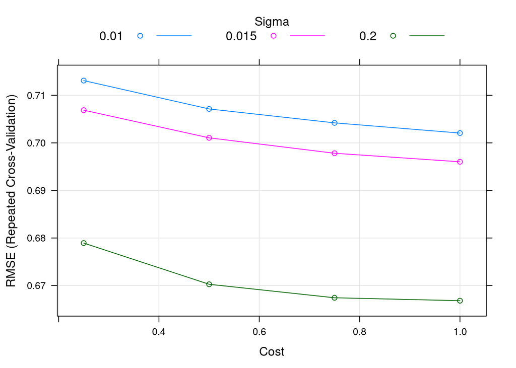

```r
# Tuning algorithm #2 - Support Vector Machine
startTimeModule <- proc.time()
set.seed(seedNum)
grid <- expand.grid(sigma = c(.01, .015, 0.2), C = c(0.25, 0.5, 0.75, 1))
fit.final2 <- train(targetVar~., data=training, method="svmRadial", metric=metricTarget, tuneGrid=grid, trControl=control)
plot(fit.final2)
```

```r
print(fit.final2)
```

```
## Support Vector Machines with Radial Basis Function Kernel
##
## 4549 samples
##   12 predictor
##
## No pre-processing
## Resampling: Cross-Validated (10 fold, repeated 3 times)
## Summary of sample sizes: 4095, 4095, 4094, 4096, 4093, 4093, ...
## Resampling results across tuning parameters:
##
##   sigma  C     RMSE       Rsquared   MAE
##   0.010  0.25  0.7130918  0.3301842  0.5513652
##   0.010  0.50  0.7071285  0.3404620  0.5458362
##   0.010  0.75  0.7042001  0.3457603  0.5430691
##   0.010  1.00  0.7020580  0.3496865  0.5412574
##   0.015  0.25  0.7068719  0.3412043  0.5454653
##   0.015  0.50  0.7010555  0.3515643  0.5400282
##   0.015  0.75  0.6978135  0.3575389  0.5371859
##   0.015  1.00  0.6960189  0.3608898  0.5356639
##   0.200  0.25  0.6789349  0.3933697  0.5104878
##   0.200  0.50  0.6702670  0.4078689  0.5018049
##   0.200  0.75  0.6674301  0.4127246  0.4983913
##   0.200  1.00  0.6668140  0.4140074  0.4970067
##
## RMSE was used to select the optimal model using the smallest value.
## The final values used for the model were sigma = 0.2 and C = 1.
```

```r
proc.time()-startTimeModule
```

```
##    user  system elapsed
## 645.082   1.609 654.607
```

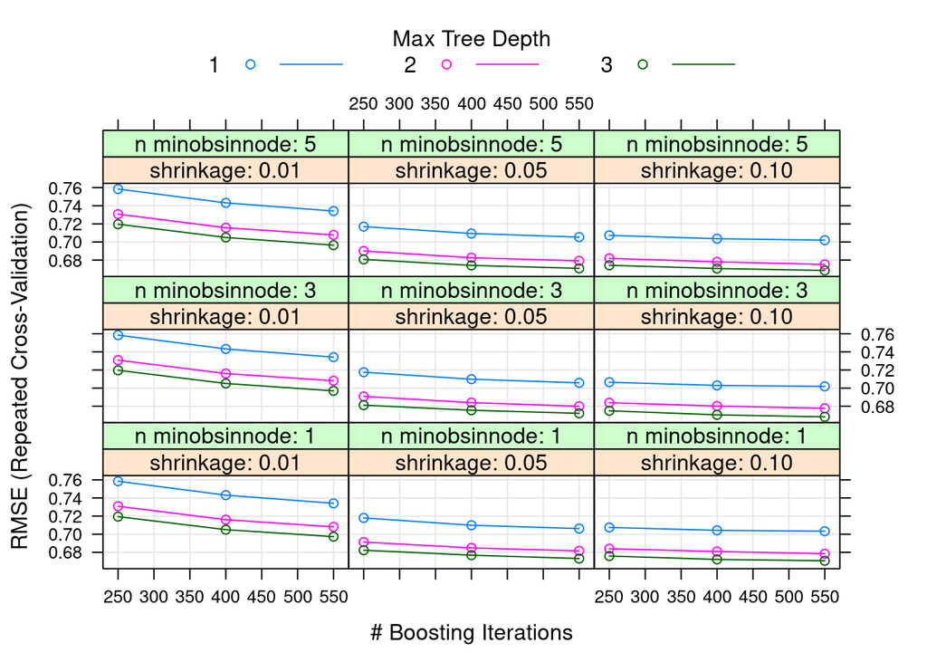

```r
# Tuning algorithm #3 - Stochastic Gradient Boosting
startTimeModule <- proc.time()
set.seed(seedNum)
grid <- expand.grid(.n.trees=c(250, 400, 550), .shrinkage=c(0.01, 0.05, 0.1), .interaction.depth=c(1, 2, 3), .n.minobsinnode=c(1, 3, 5))
fit.final3 <- train(targetVar~., data=training, method="gbm", metric=metricTarget, tuneGrid=grid, trControl=control, verbose=F)
plot(fit.final3)
```

```r
print(fit.final3)
```

```
## Stochastic Gradient Boosting
##
## 4549 samples
##   12 predictor
##
## No pre-processing
## Resampling: Cross-Validated (10 fold, repeated 3 times)
## Summary of sample sizes: 4095, 4095, 4094, 4096, 4093, 4093, ...
## Resampling results across tuning parameters:
##
##   shrinkage  interaction.depth  n.minobsinnode  n.trees  RMSE
##   0.01       1                  1               250      0.7584577
##   0.01       1                  1               400      0.7430942
##   0.01       1                  1               550      0.7341082
##   0.01       1                  3               250      0.7584776
##   0.01       1                  3               400      0.7432172
##   0.01       1                  3               550      0.7341864
##   0.01       1                  5               250      0.7584609
##   0.01       1                  5               400      0.7431943
##   0.01       1                  5               550      0.7341736
##   0.01       2                  1               250      0.7308587
##   0.01       2                  1               400      0.7160078
##   0.01       2                  1               550      0.7080665
##   0.01       2                  3               250      0.7308294
##   0.01       2                  3               400      0.7160591
##   0.01       2                  3               550      0.7081177
##   0.01       2                  5               250      0.7307344
##   0.01       2                  5               400      0.7157490
##   0.01       2                  5               550      0.7077873
##   0.01       3                  1               250      0.7193782
##   0.01       3                  1               400      0.7049951
##   0.01       3                  1               550      0.6972747
##   0.01       3                  3               250      0.7196346
##   0.01       3                  3               400      0.7050945
##   0.01       3                  3               550      0.6969436
##   0.01       3                  5               250      0.7196135
##   0.01       3                  5               400      0.7049773
##   0.01       3                  5               550      0.6964673
##   0.05       1                  1               250      0.7179583
##   0.05       1                  1               400      0.7098853
```

[output cut: 123 more lines]

```
##   0.3925833  0.5301291
##   0.3978487  0.5272917
##   0.3964246  0.5280579
##   0.4032437  0.5238892
##   0.4064045  0.5211815
##   0.3982227  0.5268051
##   0.4064609  0.5219329
##   0.4107705  0.5193276
##   0.3993095  0.5265886
##   0.4056605  0.5224374
##   0.4099569  0.5201033
##
## RMSE was used to select the optimal model using the smallest value.
## The final values used for the model were n.trees = 550,
##  interaction.depth = 3, shrinkage = 0.1 and n.minobsinnode = 3.
```

```r
proc.time()-startTimeModule
```

```
##    user  system elapsed
## 628.178   0.352 635.925
```

### 5.d) Compare Algorithms After Tuning

```r
results <- resamples(list(RF=fit.final1, SVM=fit.final2, GBM=fit.final3))
summary(results)
```

```
##
## Call:
## summary.resamples(object = results)
##
## Models: RF, SVM, GBM
## Number of resamples: 30
##
## MAE
##          Min.   1st Qu.    Median      Mean   3rd Qu.      Max. NA's
## RF  0.4219149 0.4352378 0.4521233 0.4498912 0.4627158 0.4752371    0
## SVM 0.4654667 0.4835251 0.4972570 0.4970067 0.5101960 0.5364971    0
## GBM 0.4852112 0.5072580 0.5223372 0.5193276 0.5332402 0.5452902    0
##
## RMSE
##          Min.   1st Qu.    Median      Mean   3rd Qu.      Max. NA's
## RF  0.5780582 0.5879632 0.6078463 0.6088498 0.6275254 0.6465948    0
## SVM 0.6348292 0.6496053 0.6657253 0.6668140 0.6855595 0.7012457    0
## GBM 0.6318043 0.6497748 0.6694035 0.6682569 0.6864962 0.7125679    0
##
## Rsquared
##          Min.   1st Qu.    Median      Mean   3rd Qu.      Max. NA's
## RF  0.4786313 0.4920043 0.5151165 0.5159549 0.5335513 0.5652838    0
## SVM 0.3745266 0.4003396 0.4114287 0.4140074 0.4317126 0.4681242    0
## GBM 0.3463408 0.3930962 0.4110217 0.4107705 0.4320661 0.4714829    0
```

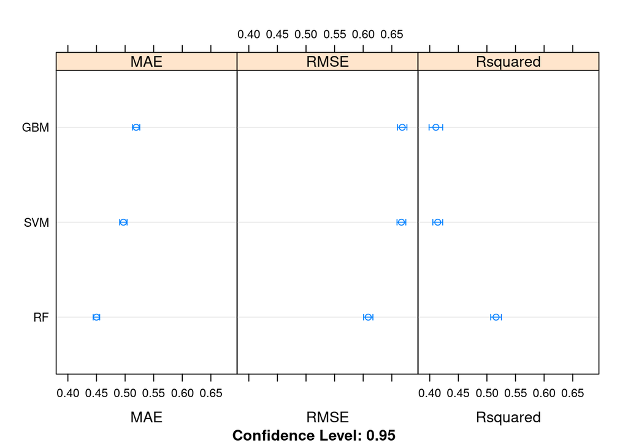

```r
dotplot(results)
```

## 6. Finalize Model and Present Results

Once we have narrow down to a model that we believe can make accurate predictions on unseen data, we are ready to finalize it. Finalizing a model may involve sub-tasks such as:

- Using an optimal model tuned to make predictions on unseen data.
- Creating a standalone model using the tuned parameters
- Saving an optimal model to file for later use.

### 6.a) Predictions on validation dataset

```r
predictions <- predict(fit.final1, newdata=validation)
valY <- validation[,totCol]
print(RMSE(predictions, valY))
```

```
## [1] 0.6416283
```

```r
print(R2(predictions, valY))
```

```
## [1] 0.4752526
```

### 6.b) Create standalone model on entire training dataset

```r
startTimeModule <- proc.time()
set.seed(seedNum)
library(randomForest)
finalModel <- randomForest(targetVar~., data=entireDataset, mtry=4, na.action=na.omit)
summary(finalModel)
```

```
##                 Length Class  Mode
## call               5   -none- call
## type               1   -none- character
## predicted       6497   -none- numeric
## mse              500   -none- numeric
## rsq              500   -none- numeric
## oob.times       6497   -none- numeric
## importance        12   -none- numeric
## importanceSD       0   -none- NULL
## localImportance    0   -none- NULL
## proximity          0   -none- NULL
## ntree              1   -none- numeric
## mtry               1   -none- numeric
## forest            11   -none- list
## coefs              0   -none- NULL
## y               6497   -none- numeric
## test               0   -none- NULL
## inbag              0   -none- NULL
## terms              3   terms  call
```

```r
proc.time()-startTimeModule
```

```
##    user  system elapsed
##  29.782   0.173  30.322
```

### 6.c) Save model for later use

```r
#saveRDS(finalModel, "./finalModel_Regression.rds")
```

```r
proc.time()-startTimeScript
```

```
##     user   system  elapsed
## 4926.789   14.065 5000.773
```